# Análisis evolución Covid-19 Chile casos y decesos (20/04/2020)

Claudio Bustos

20/4/2020

- Reportes anteriores: https://github.com/clbustos/analisis_covid19_chile

## Análisis de series de casos

La serie de casos se hace hace partir de los 25 casos, excepto para Atacama y Aysén - donde no hay casos nuevos en los últimos días, para facilitar la comparación desde un punto de un punto de partida común.

Podemos ver que la serie total sigue con una tasa prácticamente constante desde hace una semana. La región metropolitana mantiene su tasa acelerada desde hace 10 días, aunque con una leve tendencia a la baja. Araucanía, Magallanes y Valparaíso muestran también una tasa estable, en tanto que en Maule se está cortando el brote observado hace 5 días.

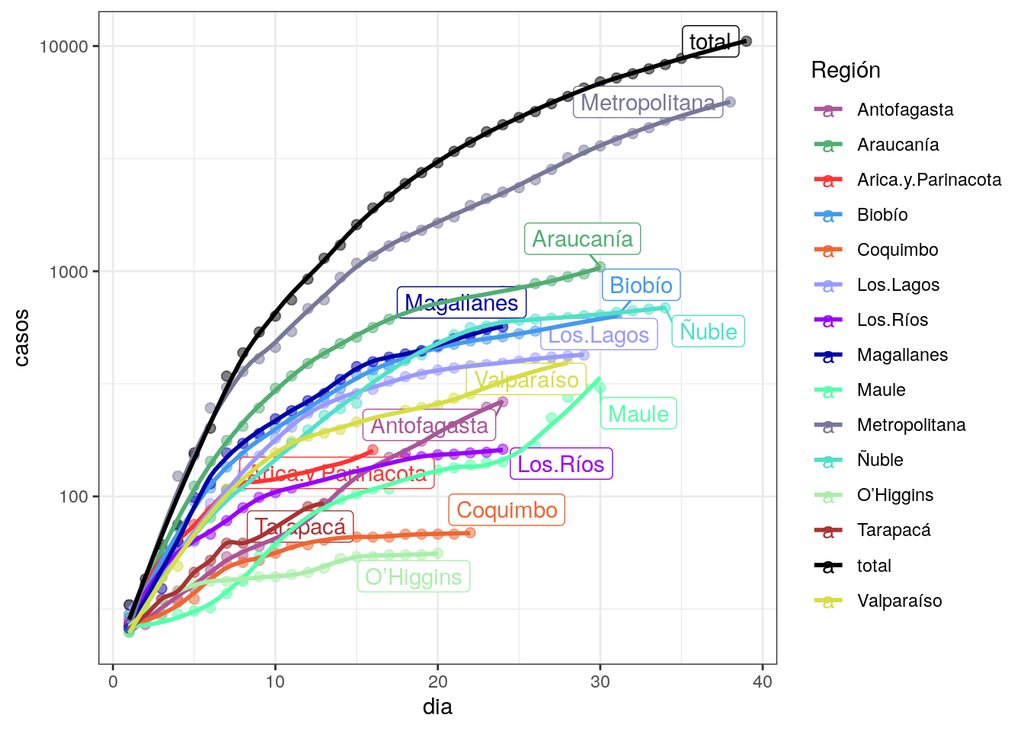

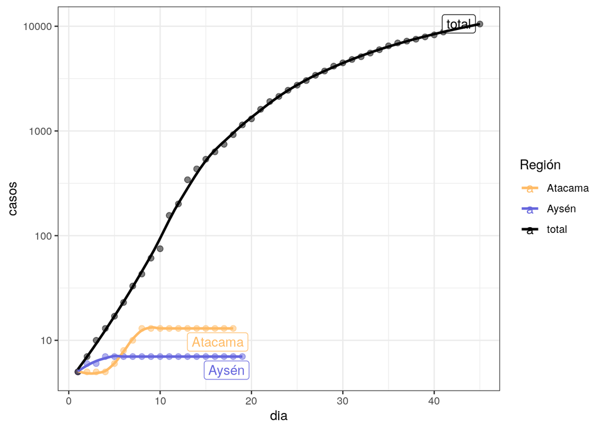

La serie por región se hace partir de los 5 primeros casos.

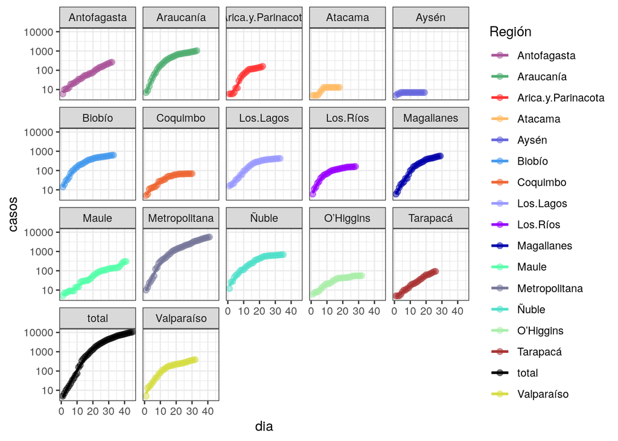

Con respecto a la cantidad de casos por día vs los del día previo, podemos ver que se mantienen tasas cercanas al 10% de los casos en Tarapacá, Antofagasta y Maule.

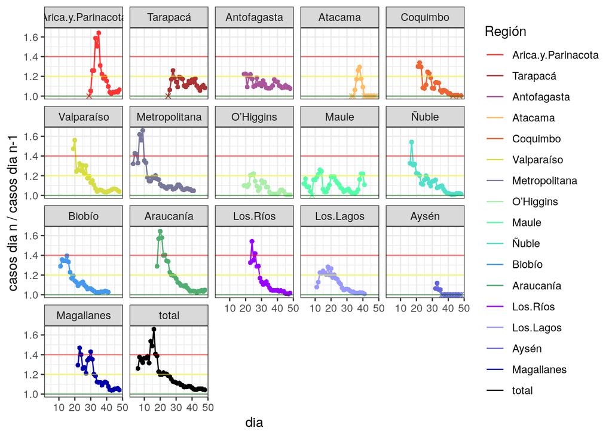

En la serie de tasas de casos nuevos, que se genera con una ventana de 5 días, se aprecia con claridad como todas las regiones presentadas mantienen la cantidad de casos día a día, excepto la Araucaní y los Ríos, con tendencias ascendentes de reciente data.

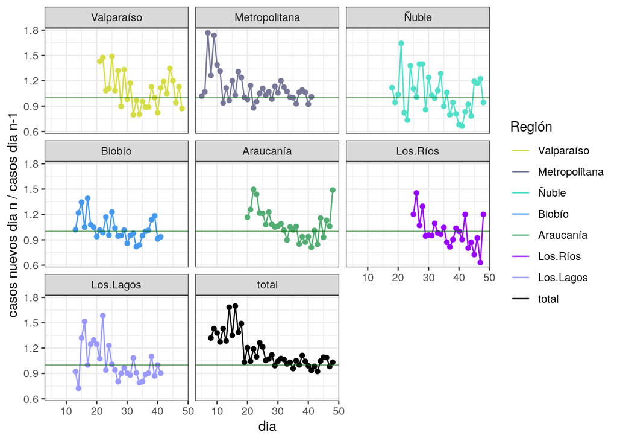

En el caso de Maule, se puede observar que recién hoy se ha desacelerado la tendencia a la aceleración de los 5 días anteriores.

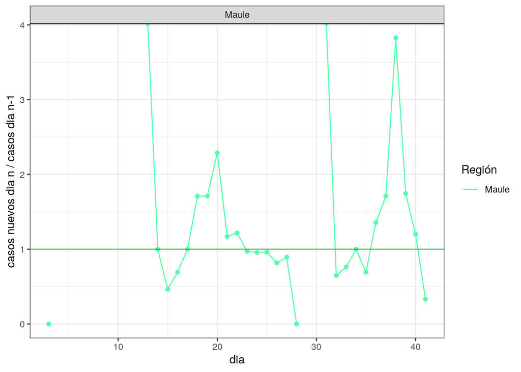

## Predicción

### Predicción para serie total

Recordemos que la regresión exponencial se eliminó, porque ya no calza con la serie total. El informe de la semana pasada mostró una subestimación constante de los modelos AR(1) + AR(4), y sobreestimación (lo que sabíamos), del modelo ARIMA. . Este último modelo se eliminará, ya que si bien los intervalos de confianza se cumplen, siempre sobreestima. A partir del análisis del resultado del algoritmo de la última semana, para la predicción total se recorta la serie a partir de lo 50 casos.

- tendencia sobre casos nuevos + AR(1) y sobre AR(4): Se modela la tendencia de los casos nuevos usando regresión exponencial, con regresión cuadradática, más la relación que existe entre mediciones contiguas. Se prueban dos modelos, uno que considera la relación solo entre cada tiempo y el anterior, AR(1), y un modelo más a largo plazo, que considera periodos de 4 días consecutivos, AR(4) . El error estándar aumenta a lo largo del tiempo, tanto por el error al calcular la tendencia, como por el componente autorregresivo. El valor medio obtenido es bastante sensible a los cambios en las mediciones finales.
- Modelo lineal cuadrático: Un modelo muy sencillo es modelar los casos totales con $ y= + _1 * dia + _2 * dia^2$, usando autocorrelación AR(2). Si bien en las pruebas muestra tener un intervalo de confianza malo y sobreestimar, tiende a tener menor error cuadrático.

|  | casos | li | ls |
| --- | --- | --- | --- |
| **Observado** | 10507 | NA | NA |
| **General: Cuadrático + AR(2)** | 10652 | 10252 | 11051 |
| **Casos nuevos : Tendencia + AR(1)** | 9491 | 8922 | 10564 |
| **Casos nuevos: Tendencia + AR(4)** | 9555 | 8982 | 10610 |

Podemos ver, al igual que en los días anteriores, que el modelo cuadrático es el más pesimista, seguido por el modelo T+AR(1), siendo el modelo AR(4) el más optimista. Considerando que los modelos AR(1) y AR(4) tienden a subestimar y el cuadrático a sobrestimar, en una semana deberíamos tener más de 12.000 casos.

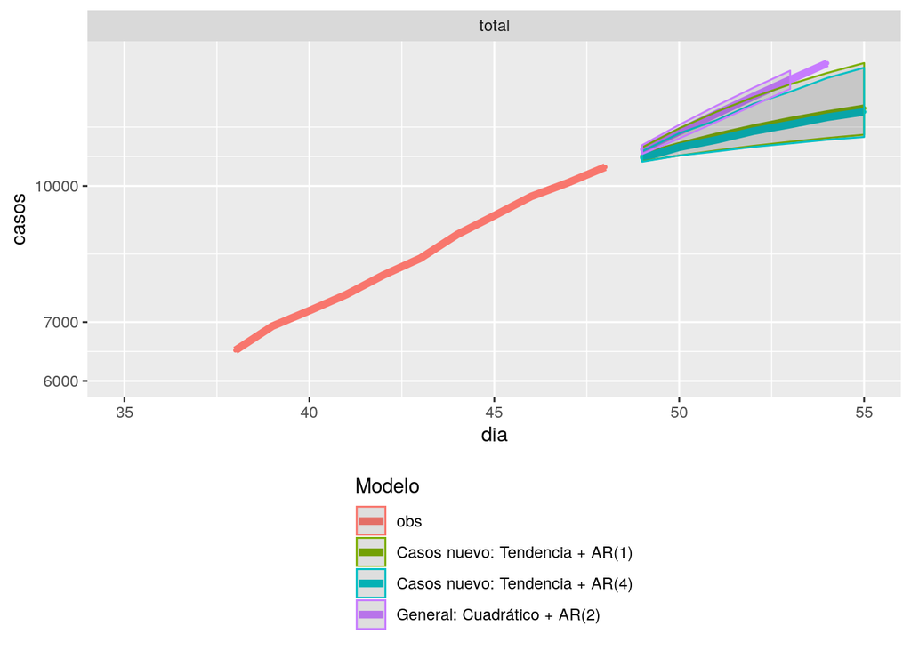

Casos nuevos: tendencia + AR(4) : total

|  | dia | casos | li | ls |
| --- | --- | --- | --- | --- |
| **38** | 49 | 10763 | 10655 | 10949 |
| **39** | 50 | 11064 | 10828 | 11476 |
| **40** | 51 | 11279 | 10944 | 11871 |
| **41** | 52 | 11540 | 11076 | 12392 |
| **42** | 53 | 11743 | 11177 | 12796 |
| **43** | 54 | 11968 | 11285 | 13265 |
| **44** | 55 | 12141 | 11367 | 13628 |

Casos nuevos: tendencia + AR(1) : total

|  | dia | casos | li | ls |
| --- | --- | --- | --- | --- |
| **38** | 49 | 10806 | 10669 | 11060 |
| **39** | 50 | 11105 | 10827 | 11625 |
| **40** | 51 | 11377 | 10971 | 12139 |
| **41** | 52 | 11629 | 11104 | 12615 |
| **42** | 53 | 11858 | 11226 | 13048 |
| **43** | 54 | 12067 | 11336 | 13442 |
| **44** | 55 | 12255 | 11435 | 13797 |

General: Modelo cuadrático : total

|  | dia | casos | li | ls |
| --- | --- | --- | --- | --- |
| **38** | 49 | 11000 | 10872 | 11128 |
| **39** | 50 | 11528 | 11323 | 11733 |
| **40** | 51 | 12076 | 11819 | 12333 |
| **41** | 52 | 12636 | 12345 | 12928 |
| **42** | 53 | 13208 | 12893 | 13523 |
| **43** | 54 | 13789 | 13458 | 14119 |
| **44** | 55 | 14380 | 14039 | 14721 |

### Predicciones para serie total usando predicción por regiones.

Otro modelo posible de análisis es usar la suma de las predicciones parciales por región. No he calculado los intervalos de confianza, porque para que sean adecuados debería considerar la covarianza entre las series de las distintas regiones.

El modelo basado en AR(1) - no se pudo calcular por hoy cuadrático - muestra un total de 13251 en una semana.

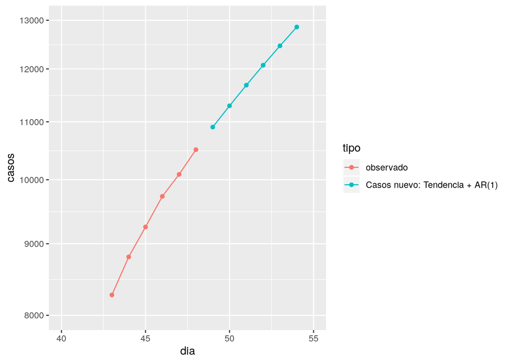

| dia | fecha | tipo | casos |
| --- | --- | --- | --- |
| 1 | 43893 | observado | 1 |
| 2 | 43894 | observado | 3 |
| 3 | 43895 | observado | 4 |
| 4 | 43896 | observado | 5 |
| 5 | 43897 | observado | 7 |
| 6 | 43898 | observado | 10 |
| 7 | 43899 | observado | 13 |
| 8 | 43900 | observado | 17 |
| 9 | 43901 | observado | 23 |
| 10 | 43902 | observado | 33 |
| 11 | 43903 | observado | 43 |
| 12 | 43904 | observado | 61 |
| 13 | 43905 | observado | 75 |
| 14 | 43906 | observado | 156 |
| 15 | 43907 | observado | 201 |
| 16 | 43908 | observado | 342 |
| 17 | 43909 | observado | 434 |
| 18 | 43910 | observado | 537 |
| 19 | 43911 | observado | 632 |
| 20 | 43912 | observado | 746 |
| 21 | 43913 | observado | 922 |
| 22 | 43914 | observado | 1142 |
| 23 | 43915 | observado | 1306 |
| 24 | 43916 | observado | 1610 |
| 25 | 43917 | observado | 1909 |
| 26 | 43918 | observado | 2139 |
| 27 | 43919 | observado | 2449 |
| 28 | 43920 | observado | 2738 |
| 29 | 43921 | observado | 3031 |
| 30 | 43922 | observado | 3404 |
| 31 | 43923 | observado | 3737 |
| 32 | 43924 | observado | 4161 |
| 33 | 43925 | observado | 4471 |
| 34 | 43926 | observado | 4815 |
| 35 | 43927 | observado | 5116 |
| 36 | 43928 | observado | 5546 |
| 37 | 43929 | observado | 5972 |
| 38 | 43930 | observado | 6501 |
| 39 | 43931 | observado | 6927 |
| 40 | 43932 | observado | 7213 |
| 41 | 43933 | observado | 7525 |
| 42 | 43934 | observado | 7917 |
| 43 | 43935 | observado | 8273 |
| 44 | 43936 | observado | 8807 |
| 45 | 43937 | observado | 9252 |
| 46 | 43938 | observado | 9730 |
| 47 | 43939 | observado | 10088 |
| 48 | 43940 | observado | 10507 |
| 49 | 43941 | Casos nuevo: Tendencia + AR(1) | 10904 |
| 50 | 43942 | Casos nuevo: Tendencia + AR(1) | 11293 |
| 51 | 43943 | Casos nuevo: Tendencia + AR(1) | 11683 |
| 52 | 43944 | Casos nuevo: Tendencia + AR(1) | 12074 |
| 53 | 43945 | Casos nuevo: Tendencia + AR(1) | 12465 |
| 54 | 43946 | Casos nuevo: Tendencia + AR(1) | 12857 |
| 55 | 43947 | Casos nuevo: Tendencia + AR(1) | 13251 |

### Predicción por regiones

Eliminaremos la predicción de Atacama y Aysén, que presentan tasas estabilizadas. Recordemos que el algoritmo inicia desde 10 casos en cada Región.

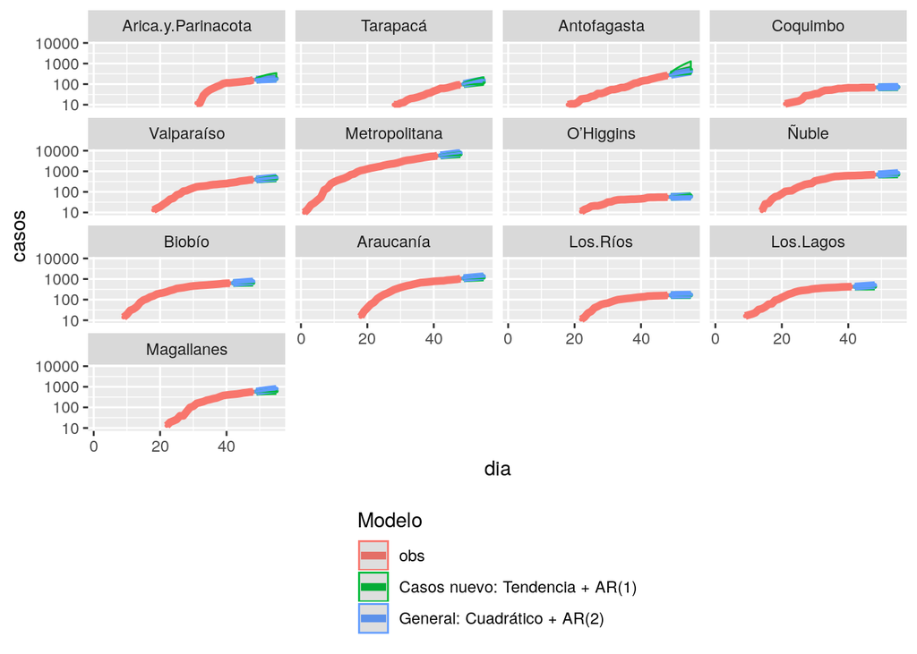

Presentamos aparte la predicción para Maule, ya que el modelo cuadrático no pudo ajustarse bien para esta región.

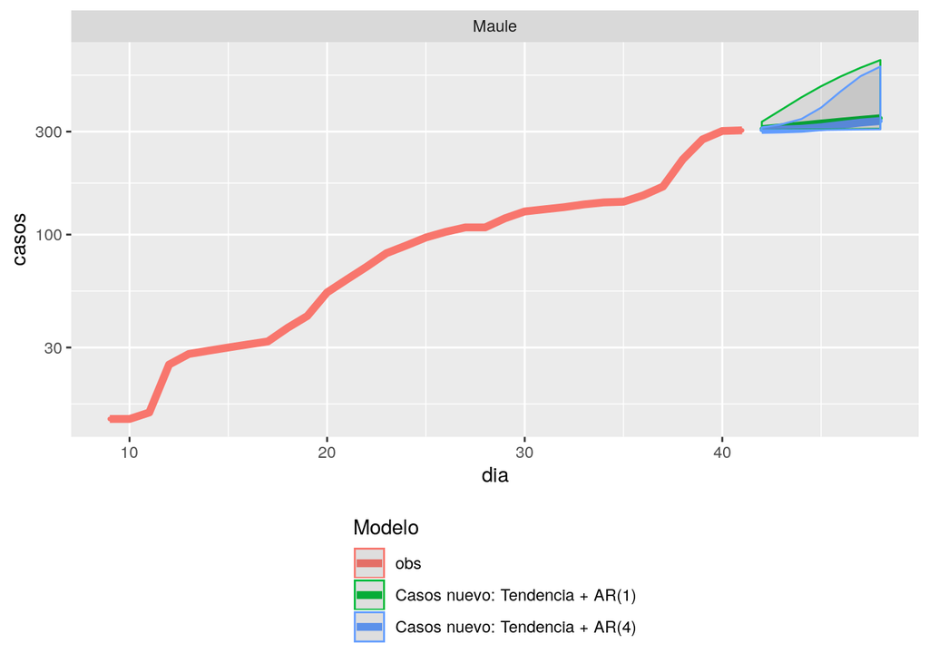

Las tablas por regiones se incluye en el Anexo I

## Ventiladores y Casos en UCI

Una primera serie es la de ventiladores disponibles. Al día de hoy se encuentran ocupados 1083, 26 más que ayer. Del total, se encuentra 6 menos habilitados.

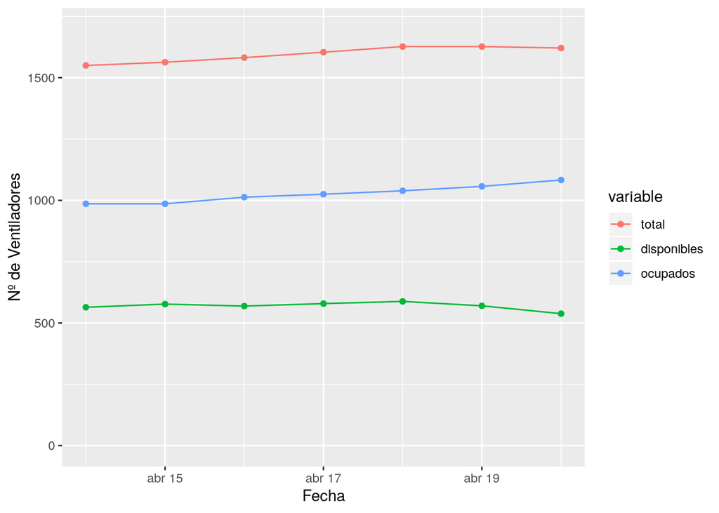

Si analizamos la serie total de pacientes en UCI para Covid-19, podemos ver que prácticamente se duplico desde inicios de mes hasta el 8 de Abril, para estabilizarse en cerca de 380 casos hasta la fecha. Hoy, en particular, observamos 377 casos.

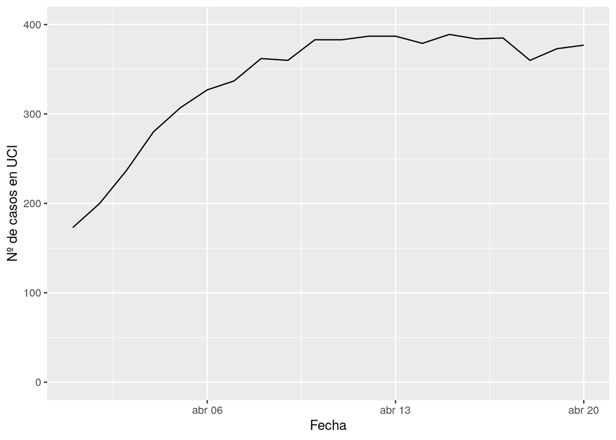

Al analizar la serie por regiones, podemos ver que en su mayoría los casos UCI se encuentran en la Región Metropolitana, siguiéndoles La Araucanía y Biobío, ambas con series descendentes desde aproximadamente 5 días.

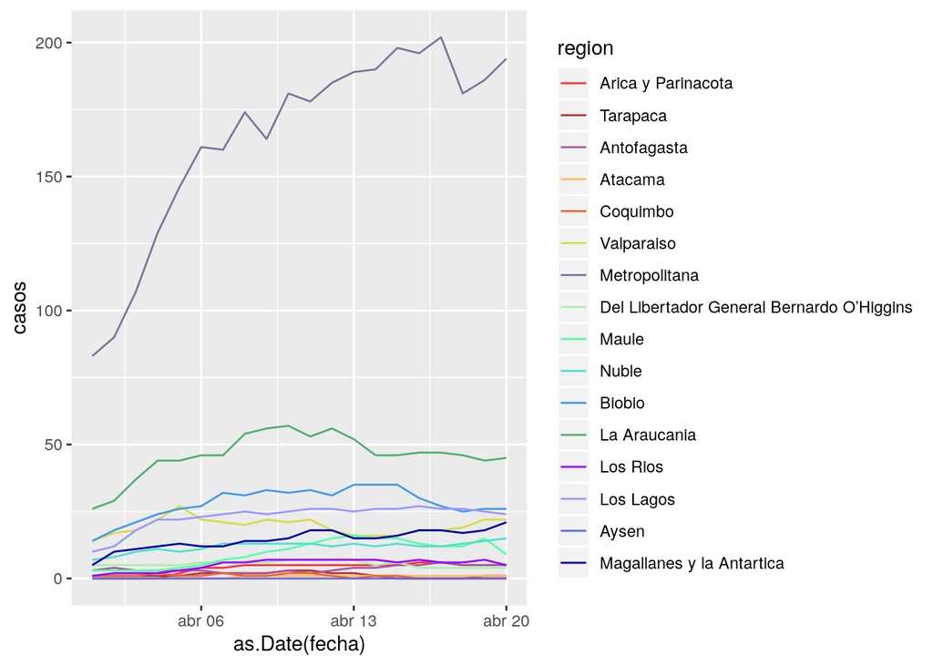

## Decesos

Si observamos la serie total de decesos, observamos una leve desaceleración de la tasa global. La tasa de la Metropolitana de los últimos 5 días está un tanto acelerada con respecto a los 5 días anteriores.

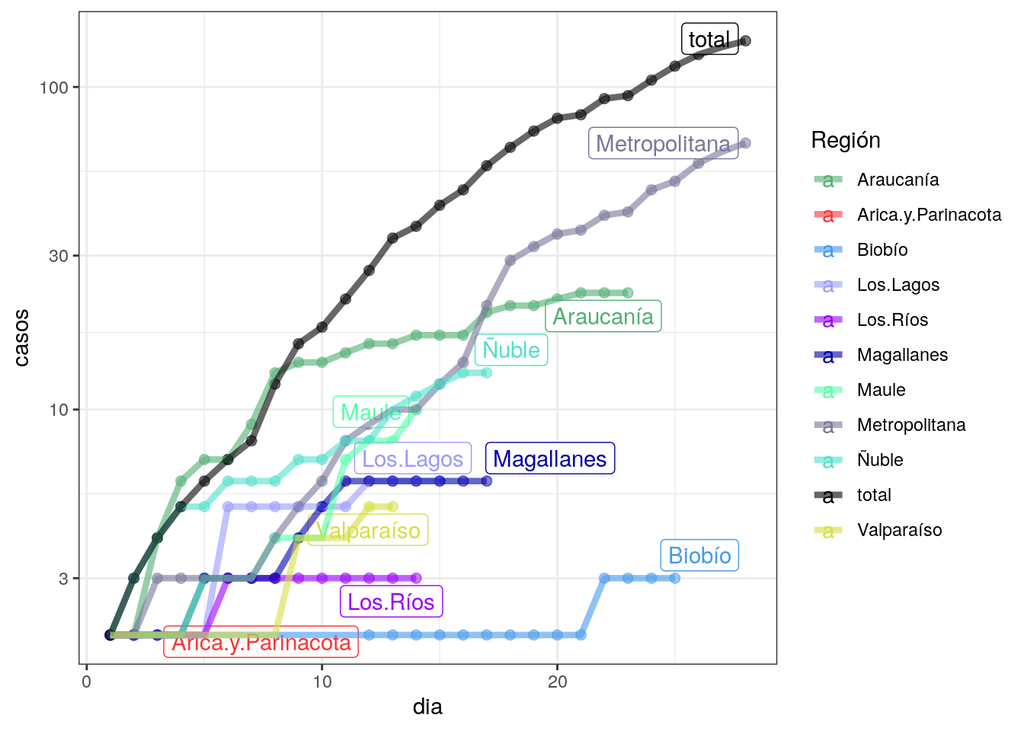

Maule y Ñuble han mantenido su tasa en el periodo considerado.

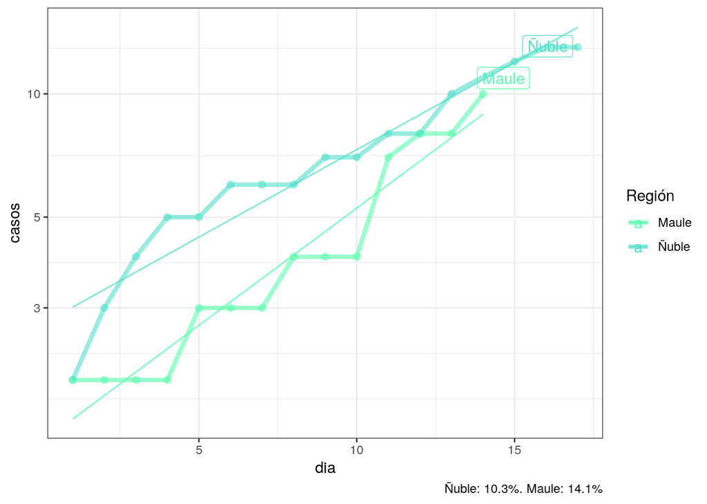

**Fuentes de información**: Principalmente, se utilizó el reporte diario del [MINSAL](https://www.minsal.cl/nuevo-coronavirus-2019-ncov/casos-confirmados-en-chile-covid-19/), usando [Wayback machine](https://archive.org/web/) para recopilar la información ya no disponible. También se ocupa la nueva serie disponible en el [Github del Ministerio de Ciencias](https://github.com/MinCiencia/Datos-COVID19).

## Anexo I: Predicciones por región

Casos nuevos: tendencia + AR(1) : Arica.y.Parinacota

|  | dia | casos | li | ls |
| --- | --- | --- | --- | --- |
| **19** | 49 | 165.9 | 161.7 | 194.8 |
| **20** | 50 | 170.4 | 162.4 | 225.6 |
| **21** | 51 | 174.5 | 163 | 253.9 |
| **22** | 52 | 178.3 | 163.5 | 279.9 |
| **23** | 53 | 181.7 | 164 | 303.6 |
| **24** | 54 | 184.8 | 164.5 | 325.1 |
| **25** | 55 | 187.7 | 164.9 | 344.4 |

Casos nuevos: tendencia + AR(1) : Tarapacá

|  | dia | casos | li | ls |
| --- | --- | --- | --- | --- |
| **22** | 49 | 98.98 | 94.7 | 114 |
| **23** | 50 | 104.2 | 96.14 | 132.6 |
| **24** | 51 | 109.3 | 97.58 | 151.1 |
| **25** | 52 | 114.2 | 98.95 | 168.7 |
| **26** | 53 | 118.9 | 100.2 | 185.5 |
| **27** | 54 | 123.3 | 101.5 | 201.4 |
| **28** | 55 | 127.5 | 102.6 | 216.2 |

Casos nuevos: tendencia + AR(1) : Antofagasta

|  | dia | casos | li | ls |
| --- | --- | --- | --- | --- |
| **32** | 49 | 289.9 | 269.4 | 376.3 |
| **33** | 50 | 316 | 275.4 | 490.4 |
| **34** | 51 | 345.7 | 282.1 | 620.5 |
| **35** | 52 | 378.2 | 289.6 | 763.1 |
| **36** | 53 | 414.2 | 297.8 | 920.7 |
| **37** | 54 | 453.8 | 306.8 | 1094 |
| **38** | 55 | 497.6 | 316.8 | 1286 |

Casos nuevos: tendencia + AR(1) : Coquimbo

|  | dia | casos | li | ls |
| --- | --- | --- | --- | --- |
| **29** | 49 | 69.55 | 69.14 | 71.18 |
| **30** | 50 | 70.03 | 69.26 | 73.08 |
| **31** | 51 | 70.41 | 69.36 | 74.61 |
| **32** | 52 | 70.72 | 69.43 | 75.83 |
| **33** | 53 | 70.96 | 69.49 | 76.8 |
| **34** | 54 | 71.15 | 69.54 | 77.56 |
| **35** | 55 | 71.3 | 69.58 | 78.14 |

Casos nuevos: tendencia + AR(1) : Valparaíso

|  | dia | casos | li | ls |
| --- | --- | --- | --- | --- |
| **32** | 49 | 398.4 | 391.2 | 421.1 |
| **33** | 50 | 408.7 | 394.4 | 454.2 |
| **34** | 51 | 418.5 | 397.5 | 485.8 |
| **35** | 52 | 427.9 | 400.4 | 515.8 |
| **36** | 53 | 436.6 | 403.2 | 544.1 |
| **37** | 54 | 444.9 | 405.7 | 570.6 |
| **38** | 55 | 452.6 | 408.1 | 595.4 |

Casos nuevos: tendencia + AR(1) : Metropolitana

|  | dia | casos | li | ls |
| --- | --- | --- | --- | --- |
| **42** | 42 | 5848 | 5729 | 6131 |
| **43** | 43 | 6031 | 5804 | 6580 |
| **44** | 44 | 6201 | 5873 | 6996 |
| **45** | 45 | 6358 | 5937 | 7380 |
| **46** | 46 | 6503 | 5996 | 7735 |
| **47** | 47 | 6635 | 6050 | 8059 |
| **48** | 48 | 6755 | 6099 | 8354 |

Casos nuevos: tendencia + AR(1) : O’Higgins

|  | dia | casos | li | ls |
| --- | --- | --- | --- | --- |
| **28** | 49 | 56.99 | 56.3 | 59.23 |
| **29** | 50 | 57.94 | 56.59 | 62.39 |
| **30** | 51 | 58.87 | 56.87 | 65.45 |
| **31** | 52 | 59.77 | 57.14 | 68.41 |
| **32** | 53 | 60.64 | 57.41 | 71.29 |
| **33** | 54 | 61.49 | 57.67 | 74.08 |
| **34** | 55 | 62.31 | 57.92 | 76.79 |

Casos nuevos: tendencia + AR(1) : Ñuble

|  | dia | casos | li | ls |
| --- | --- | --- | --- | --- |
| **36** | 49 | 692 | 688.2 | 708.8 |
| **37** | 50 | 696.1 | 689.1 | 726.4 |
| **38** | 51 | 699.4 | 689.9 | 740.8 |
| **39** | 52 | 702.1 | 690.5 | 752.6 |
| **40** | 53 | 704.3 | 691 | 762.2 |
| **41** | 54 | 706 | 691.4 | 769.8 |
| **42** | 55 | 707.4 | 691.7 | 775.9 |

Casos nuevos: tendencia + AR(1) : Biobío

|  | dia | casos | li | ls |
| --- | --- | --- | --- | --- |
| **34** | 42 | 634.7 | 629.9 | 645.4 |
| **35** | 43 | 642.2 | 633.2 | 662.5 |
| **36** | 44 | 648.8 | 636.1 | 677.4 |
| **37** | 45 | 654.4 | 638.6 | 690.1 |
| **38** | 46 | 659.2 | 640.7 | 700.9 |
| **39** | 47 | 663.2 | 642.5 | 710.1 |
| **40** | 48 | 666.6 | 644 | 717.8 |

Casos nuevos: tendencia + AR(1) : Araucanía

|  | dia | casos | li | ls |
| --- | --- | --- | --- | --- |
| **32** | 49 | 1077 | 1058 | 1124 |
| **33** | 50 | 1102 | 1067 | 1189 |
| **34** | 51 | 1124 | 1076 | 1246 |
| **35** | 52 | 1145 | 1084 | 1299 |
| **36** | 53 | 1164 | 1091 | 1348 |
| **37** | 54 | 1181 | 1098 | 1393 |
| **38** | 55 | 1197 | 1104 | 1433 |

Casos nuevos: tendencia + AR(1) : Los.Ríos

|  | dia | casos | li | ls |
| --- | --- | --- | --- | --- |
| **28** | 49 | 162.7 | 162.3 | 163.9 |
| **29** | 50 | 163.9 | 162.7 | 167.3 |
| **30** | 51 | 164.6 | 162.9 | 169.5 |
| **31** | 52 | 165.3 | 163.2 | 171.4 |
| **32** | 53 | 165.8 | 163.3 | 172.9 |
| **33** | 54 | 166.2 | 163.5 | 174.1 |
| **34** | 55 | 166.5 | 163.6 | 175 |

Casos nuevos: tendencia + AR(1) : Los.Lagos

|  | dia | casos | li | ls |
| --- | --- | --- | --- | --- |
| **34** | 42 | 426 | 424.7 | 429.6 |
| **35** | 43 | 427.5 | 425.2 | 434 |
| **36** | 44 | 428.7 | 425.6 | 437.2 |
| **37** | 45 | 429.5 | 425.9 | 439.6 |
| **38** | 46 | 430.1 | 426.1 | 441.2 |
| **39** | 47 | 430.5 | 426.3 | 442.4 |
| **40** | 48 | 430.7 | 426.4 | 443.2 |

Casos nuevos: tendencia + AR(1) : Magallanes

|  | dia | casos | li | ls |
| --- | --- | --- | --- | --- |
| **28** | 49 | 579.5 | 569.6 | 617.4 |
| **29** | 50 | 590.6 | 572.4 | 660.4 |
| **30** | 51 | 599.9 | 574.8 | 696.5 |
| **31** | 52 | 607.5 | 576.8 | 726.1 |
| **32** | 53 | 613.6 | 578.3 | 750 |
| **33** | 54 | 618.5 | 579.6 | 769 |
| **34** | 55 | 622.3 | 580.6 | 783.8 |

General: cuadrático + AR(2) : Arica.y.Parinacota

|  | dia | casos | li | ls |
| --- | --- | --- | --- | --- |
| **19** | 49 | 166.5 | 155.8 | 177.2 |
| **20** | 50 | 167.9 | 154.6 | 181.2 |
| **21** | 51 | 169.2 | 155.8 | 182.7 |
| **22** | 52 | 171.6 | 158.1 | 185.1 |
| **23** | 53 | 174.3 | 160.8 | 187.9 |
| **24** | 54 | 176.9 | 163.3 | 190.5 |
| **25** | 55 | 178.9 | 165.3 | 192.4 |

General: cuadrático + AR(2) : Tarapacá

|  | dia | casos | li | ls |
| --- | --- | --- | --- | --- |
| **22** | 49 | 101.9 | 97.68 | 106 |
| **23** | 50 | 111 | 106.6 | 115.5 |
| **24** | 51 | 119.7 | 115.2 | 124.1 |
| **25** | 52 | 128.3 | 123.8 | 132.7 |
| **26** | 53 | 137.3 | 132.8 | 141.7 |
| **27** | 54 | 146.7 | 142.2 | 151.1 |
| **28** | 55 | 156.4 | 151.9 | 160.8 |

General: cuadrático + AR(2) : Antofagasta

|  | dia | casos | li | ls |
| --- | --- | --- | --- | --- |
| **32** | 49 | 281.2 | 272.9 | 289.5 |
| **33** | 50 | 299.9 | 289.9 | 309.9 |
| **34** | 51 | 319.4 | 308.6 | 330.2 |
| **35** | 52 | 339.7 | 328.4 | 351 |
| **36** | 53 | 360.7 | 349.1 | 372.2 |
| **37** | 54 | 382.4 | 370.7 | 394.1 |
| **38** | 55 | 404.8 | 393.1 | 416.6 |

General: cuadrático + AR(2) : Coquimbo

|  | dia | casos | li | ls |
| --- | --- | --- | --- | --- |
| **29** | 49 | 70.33 | 65.55 | 75.11 |
| **30** | 50 | 71.48 | 64.89 | 78.06 |
| **31** | 51 | 72.34 | 64.98 | 79.71 |
| **32** | 52 | 72.96 | 65.28 | 80.64 |
| **33** | 53 | 73.36 | 65.56 | 81.16 |
| **34** | 54 | 73.58 | 65.73 | 81.43 |
| **35** | 55 | 73.64 | 65.77 | 81.51 |

General: cuadrático + AR(2) : Valparaíso

|  | dia | casos | li | ls |
| --- | --- | --- | --- | --- |
| **32** | 49 | 402.6 | 388.4 | 416.8 |
| **33** | 50 | 418.2 | 399.4 | 436.9 |
| **34** | 51 | 433.9 | 412.9 | 455 |
| **35** | 52 | 449.9 | 427.6 | 472.2 |
| **36** | 53 | 466.1 | 443.1 | 489.1 |
| **37** | 54 | 482.4 | 459 | 505.8 |
| **38** | 55 | 498.9 | 475.2 | 522.5 |

General: cuadrático + AR(2) : Metropolitana

|  | dia | casos | li | ls |
| --- | --- | --- | --- | --- |
| **42** | 42 | 5940 | 5853 | 6027 |
| **43** | 43 | 6252 | 6131 | 6374 |
| **44** | 44 | 6571 | 6438 | 6703 |
| **45** | 45 | 6892 | 6758 | 7026 |
| **46** | 46 | 7218 | 7084 | 7353 |
| **47** | 47 | 7550 | 7416 | 7684 |
| **48** | 48 | 7888 | 7754 | 8023 |

General: cuadrático + AR(2) : O’Higgins

|  | dia | casos | li | ls |
| --- | --- | --- | --- | --- |
| **28** | 49 | 56.82 | 53.98 | 59.65 |
| **29** | 50 | 57.39 | 53.68 | 61.09 |
| **30** | 51 | 57.77 | 53.89 | 61.64 |
| **31** | 52 | 58.02 | 54.13 | 61.9 |
| **32** | 53 | 58.17 | 54.29 | 62.06 |
| **33** | 54 | 58.25 | 54.36 | 62.15 |
| **34** | 55 | 58.25 | 54.36 | 62.15 |

General: cuadrático + AR(2) : Ñuble

|  | dia | casos | li | ls |
| --- | --- | --- | --- | --- |
| **36** | 49 | 703.9 | 673 | 734.8 |
| **37** | 50 | 723.8 | 673.5 | 774 |
| **38** | 51 | 744.6 | 680.6 | 808.6 |
| **39** | 52 | 765.5 | 692 | 839 |
| **40** | 53 | 786.3 | 706.1 | 866.4 |
| **41** | 54 | 806.6 | 721.8 | 891.5 |
| **42** | 55 | 826.6 | 738.5 | 914.8 |

General: cuadrático + AR(2) : Biobío

|  | dia | casos | li | ls |
| --- | --- | --- | --- | --- |
| **34** | 42 | 643 | 625.7 | 660.4 |
| **35** | 43 | 662.7 | 635 | 690.4 |
| **36** | 44 | 683.3 | 648.7 | 717.8 |
| **37** | 45 | 704 | 664.9 | 743 |
| **38** | 46 | 724.5 | 682.6 | 766.5 |
| **39** | 47 | 744.9 | 701.1 | 788.7 |
| **40** | 48 | 765 | 720.1 | 810 |

General: cuadrático + AR(2) : Araucanía

|  | dia | casos | li | ls |
| --- | --- | --- | --- | --- |
| **32** | 49 | 1099 | 1070 | 1129 |
| **33** | 50 | 1146 | 1100 | 1191 |
| **34** | 51 | 1189 | 1133 | 1245 |
| **35** | 52 | 1231 | 1169 | 1293 |
| **36** | 53 | 1273 | 1207 | 1338 |
| **37** | 54 | 1315 | 1248 | 1383 |
| **38** | 55 | 1358 | 1289 | 1426 |

General: cuadrático + AR(2) : Los.Ríos

|  | dia | casos | li | ls |
| --- | --- | --- | --- | --- |
| **28** | 49 | 165.7 | 160.4 | 171 |
| **29** | 50 | 168.2 | 162 | 174.3 |
| **30** | 51 | 170 | 163.8 | 176.2 |
| **31** | 52 | 171.5 | 165.3 | 177.7 |
| **32** | 53 | 172.8 | 166.6 | 179 |
| **33** | 54 | 173.8 | 167.6 | 180 |
| **34** | 55 | 174.6 | 168.4 | 180.8 |

General: cuadrático + AR(2) : Los.Lagos

|  | dia | casos | li | ls |
| --- | --- | --- | --- | --- |
| **34** | 42 | 431.8 | 415.8 | 447.8 |
| **35** | 43 | 442.2 | 414.2 | 470.3 |
| **36** | 44 | 454.1 | 416.5 | 491.7 |
| **37** | 45 | 466.5 | 421.7 | 511.3 |
| **38** | 46 | 479.2 | 429.1 | 529.2 |
| **39** | 47 | 491.8 | 437.9 | 545.6 |
| **40** | 48 | 504.2 | 447.6 | 560.7 |

General: cuadrático + AR(2) : Magallanes

|  | dia | casos | li | ls |
| --- | --- | --- | --- | --- |
| **28** | 49 | 594.1 | 571.4 | 616.9 |
| **29** | 50 | 626.8 | 594.2 | 659.4 |
| **30** | 51 | 660.5 | 623.1 | 697.8 |
| **31** | 52 | 694 | 654.5 | 733.5 |
| **32** | 53 | 727.3 | 686.9 | 767.7 |
| **33** | 54 | 760.5 | 719.7 | 801.2 |
| **34** | 55 | 793.8 | 752.9 | 834.6 |